# R Users Group Week 3

# Introduction

This week we will begin working with data frames. Data frames are the heart of R and you will work with to use the statistical and graphical functionality of R.

If you have experience with Access, a data frame is like a table in access. Each row is an observation about something. Multiple data frames like a relational data base.

For example, if you run a hospital you will want to keep track of your patients. One data frame could be a patient list. You’d have a separate row for each patient with their name, address, insurance company, etc. You might want to link that to medical data. So, another data frame could be measurements such as temperature, blood pressure, heart rate, and other items that constitute a health assessment and whether tha patient is getting sicker or improving. A third data base would track of procedures both for billing and clinical purposes. In that data frame you would keep track of what was done, by whom, billing codes, etc.

R has terrific facilities for doing analytical on data in this type of structure. Since medical data is structured much like I described above, R has become a leading analytical platform for medical and health researchers. R is taught for this purpose at leading medical schools including John Hopkins and Vanderbilt.

Back to finance. . .

# Data Set

Last week, we worked with stock prices and calculated returns for Apple, IBM and Microsoft. This week, we continue to look at the same securities, but I have added PE ratio. “PE” stands price/earnings and it is the ratio of the price stock divided by the earnings or profit per share. It is a measure of value. If two companies both have $1 per share in earnings, but one stock trades for $10 and the other trades for $15 then the respective PE ratios are 10 and 15. Other things equal, the 15 PE stock would be regarded as more expensive than the 10 PE stock.

Let’s read in the data.

```r
stockdat=read.csv("longstockdat.csv")
stockdat$date=as.Date(stockdat$date)
head(stockdat)
```

```
##   X        ticker       date TOT_RETURN_INDEX_GROSS_DVDS PE_RATIO
## 1 1 IBM US EQUITY 2006-12-29                     97.1500  15.9524
## 2 2 IBM US EQUITY 2007-01-31                     99.1500  16.2808
## 3 3 IBM US EQUITY 2007-02-28                     93.2400  15.2611
## 4 4 IBM US EQUITY 2007-03-30                     94.5643  15.1543
## 5 5 IBM US EQUITY 2007-04-30                    102.5399  16.4325
## 6 6 IBM US EQUITY 2007-05-31                    107.3454  17.1383
```

This data is in “long” format. Each row represents an observation about a security (tracking the price and PE) as of a particular date. By the way, this is an unmodified version of how Bloomberg delivered the data; so, Bloomberg operates by default in long data mode.

Another way to look at the data is to convert it to wide format. R has a package called “tidyr” that helps you make this conversion. Let’s look at the PE data in “wide” format.

```r
require(tidyr)
widepe=spread(stockdat[,c(2,3,5)],ticker,PE_RATIO) #I am only operating on the columns 2, 3, and 5 of the data frame
head(widepe)
```

```
##         date AAPL US EQUITY IBM US EQUITY MSFT US EQUITY
## 1 2006-12-29        30.6282       15.9524        24.2764
## 2 2007-01-31        30.9495       16.2808        25.0894
## 3 2007-02-28        30.5451       15.2611        22.9024
## 4 2007-03-30        29.3091       15.1543        19.9071
## 5 2007-04-30        31.4826       16.4325        21.3857
## 6 2007-05-31        38.2306       17.1383        21.9215
```

Now it is arranged with the tickers as column headers facilitating a human readable comparison of the PE ratios of the three stocks on a given date. In addition to improved human readability, you will find wide format easier to work with for certain types of number crunching.

Notice what you have lost, by converting to wide format. First we’ve lost the price data all together. In wide format, you can only present one type of observation. If you want to represent two (or more) pieces of information (price and PE in our case), you will need a long format for your data. Additionally the data set itself no longer identifies that the values in the data are PE ratios. You have to know that or keep track of that outside the data set. For these reasons, data scientists generally regard long format data as the way to go. As a practical matter, you will want to be able to work with both long and wide formats and know how to convert back and forth.

By the way the gather function allows you to convert from wide to long data. Here you go!

```r
backtolong=gather(widepe,ticker,pe,-date)
head(backtolong)
```

```
##         date         ticker      pe
## 1 2006-12-29 AAPL US EQUITY 30.6282
## 2 2007-01-31 AAPL US EQUITY 30.9495
## 3 2007-02-28 AAPL US EQUITY 30.5451
## 4 2007-03-30 AAPL US EQUITY 29.3091
## 5 2007-04-30 AAPL US EQUITY 31.4826
## 6 2007-05-31 AAPL US EQUITY 38.2306
```

This is tricky and you need to practice it. The R users group from Milano, Italy has a nice blog post on this. Go to Milano R Users Group and search their blog for “tidyr”.

# Working with long form data

```r
unique(stockdat$ticker)  # what stocks are in the data set?
```

```
## [1] IBM US EQUITY  AAPL US EQUITY MSFT US EQUITY
## Levels: AAPL US EQUITY IBM US EQUITY MSFT US EQUITY
```

```r
length(unique(stockdat$ticker))   # how many different stocks are there?
```

```
## [1] 3
```

```r
apple=subset(stockdat,ticker=="AAPL US EQUITY") # extract apple
head(apple)
```

```
##       X         ticker       date TOT_RETURN_INDEX_GROSS_DVDS PE_RATIO
## 122 122 AAPL US EQUITY 2006-12-29                     12.1200  30.6282
## 123 123 AAPL US EQUITY 2007-01-31                     12.2471  30.9495
## 124 124 AAPL US EQUITY 2007-02-28                     12.0871  30.5451
## 125 125 AAPL US EQUITY 2007-03-30                     13.2729  29.3091
## 126 126 AAPL US EQUITY 2007-04-30                     14.2571  31.4826
## 127 127 AAPL US EQUITY 2007-05-31                     17.3130  38.2306
```

```r
aggregate(stockdat$PE_RATIO,by=list(stockdat$ticker),mean)
```

```
##          Group.1        x
## 1 AAPL US EQUITY 18.37111
## 2  IBM US EQUITY 12.59068
## 3 MSFT US EQUITY 15.74333
```

# working with wide form data

```r
colnames(widepe)
```

```
## [1] "date"           "AAPL US EQUITY" "IBM US EQUITY"  "MSFT US EQUITY"
```

```r
colnames(widepe)[-1]  #what are the tickers
```

```
## [1] "AAPL US EQUITY" "IBM US EQUITY"  "MSFT US EQUITY"
```

```r
ncol(widepe)-1  #how many are there
```

```
## [1] 3
```

```r
apple=widepe$`AAPL US EQUITY`  #extract apple
apply(widepe[,-1],2,mean)  #calculate the mean PE for each stock
```

```
## AAPL US EQUITY  IBM US EQUITY MSFT US EQUITY
##       18.37111       12.59068       15.74333
```

# Using ggplot to plot long form data

Note: ggplot only works with long form data. If you have wide form, you need to convert to long form.

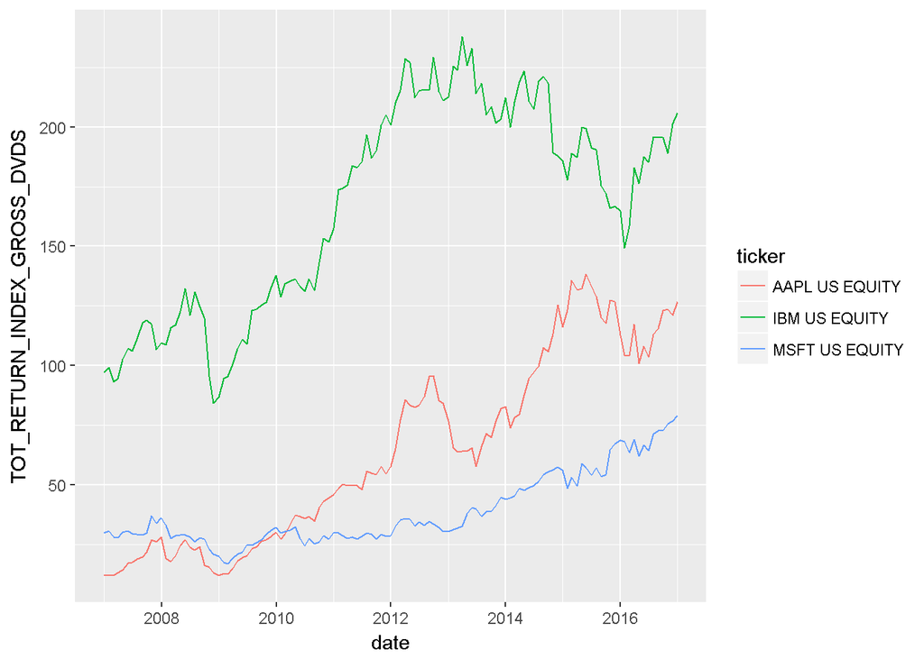

```r
require(ggplot2)
ggplot(stockdat,aes(x=date,y=TOT_RETURN_INDEX_GROSS_DVDS,group=ticker,color=ticker))+
  geom_line()
```

# Homework

Write a report about these three stocks using both the PE data and return information from last week. Is there a relationship between PE and returns?

Prepare a barplot using ggplot2 comparing the mean PEs of the three stocks.

Prepare a line chart of the three comparing growth of a dollar instead of the prices above.